# Arimax M5 Competition

Carlos Alberto Cerro Espinal, Carlos Andres Cuartas Murillo, Daniel Enrique Pinto Restrepo, Daniel Roman Ramirez, Santiago Mejia Chitiva

May 4 2020

# Introduction

# The M5 Competition and the data

## The M5 Competition

The M5 competition is sponsored by The M Open Forecasting Center (MOFC) associated with the University of Nicosia (UNIC) which is the largest university in Cyprus. The mission of the MOFC “is to conduct multidisciplinary research in the area of forecasting with emphasis on accuracy and uncertainty and to expand the utilization of forecasting to business firms by identifying their needs, suggesting the most appropriate way of fulfilling them, demonstrating its benefits in reducing costs and/or improving profits while also avoiding untested practices.” This is why the MOFC has launched different competitions to adress different problems of forecasting, the M5 is the fifth competition held by the MOFC with a focus on intermittency, which is sporadic demand including zeros. The dataset for the competitions was provided by Walmart with hierachichal sales data, starting at item level aggregating to departments, categories and then stroes in three geographical areas of the United States(US): California, Texas, and Wisconsin.

## The data

As mentioned earlier we have three geographical areas of the United States: California, Texas, and Wisconsin. Each of this areas have stores, California is the leading one with four, Wisconsin and Texas have three stores each one, this give us a total of 10 stores. In each of this stores are sold three categories, Household, Foods and Hobbies, then this categories are divides in a total of 7 departments. Finally we have a total of 3049 items all over the mentioned departments and categories. The main goal is to forecast this 3049 items in each of the mentioned stores, this give us a total of 30490 time series to forecast. To do so, we have information of the weekly selling prices of each of the items for their different locations, we also have information of the special dates/events in the US (i.e mothers day, independence day, NBA finals, etc), finally we have a information of the Supplemental Nutrition Assitance Program (SNAP), which “provides nutrition benefits to supplement the food budget of needy families so they can purchase healthy food and move towards self-sufficiency.” This last information may be very significant for the Foods category. To finish this section, and give a more clear information of the available data, here is a summary chart of the mentioned above.

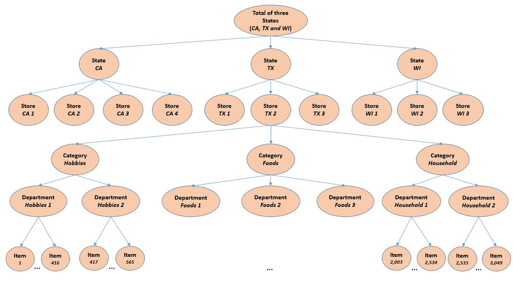

# Code And Methodology

## Methodology: Hierarchical Arimax

The problem we have here is an obvious problem of hierarchical time series, in the theory of hierarchical time series there are several approaches to forecast all the series. First is the bottom up approach, the objective is to forecast the lowest level of the hierarchy and then sum up to achieve the forecast of the highest leve; the second approach is the top-down approach, that is, you forecast a high level of the process and to get the forecast of the lowest levels you multiply this forecast by the historical proportions of the lowest level. In this technical document, we took a top down approach.

Now we have clear the type of problem we have, but what approach we will take? Here we used an Arimax approach to forecast the series, but, why Arimax? Because, when one works with time series you have to take into account the autoregressive and moving average components, but also, that the series must be stationary to perform well with the econometrics assumptions.

## Code

```r
#Create the calendar variables
#First we create factor variable of months
calendar$month_2 = factor(calendar$month,
                          levels = unique(calendar$month),
                          labels = c("enero","febrero","marzo","abril","mayo","junio","julio",
                                     "agosto","septiembre","octubre","noviembre","diciembre"))
#Then we create a factor variable for our events
calendar$events = factor(calendar$event_name_1,
       levels = unique(calendar$event_name_1),
       labels = c("none","superbowl","valentinesday","presidentday","lentstart","lentweek2","stpatricksday",
                  "purim_end","orthodoxeaster","pesach_end","cinco_de_mayo","mothers_day","memorialday",
                  "nbafinalstart","nbafinalsend","fathers_day","independence_day","radaman_starts",
                  "eid_alfitr","laborday","columbusday","haloween","eidaladha","veteransday",
                  "thanksgiving","christmas","chanukahend","newyear","orthodoxchristmas",
                  "martinluterkingday","easter"))


#Generate variables if there is an event tomorrow or the day after tomorro
calendar$dumm_evento = ifelse(calendar$events == "none",0,1)
#Date tomorrow
calendar$evento_manana = lead(calendar$dumm_evento)
calendar[is.na(calendar$evento_manana),"evento_manana"] = 0
#Date after tomorrow
calendar$evento_pasado_manana = lead(calendar$dumm_evento,n=2)
calendar[is.na(calendar$evento_pasado_manana),"evento_pasado_manana"] = 0
#Month day variable
```

We have already created our date variables, with that already done, we proceed to generate a data frame that contains only the data of one store, in this first case is the “CA_1” store, we proceed to generate the code for one store and one department, after that we will scalate the code to generate an Arimax model by each department in each store, this will give us a total of 70 Arimax models. After this, we will generate the the historical proportions of the items in each department in each store and multiply this to the forecast of the department, this will give us the predicition for each item. So let’s begin, first we filter the “CA_1” store

```r
#First we generate file for each store
ca1 = sales_train_validation %>% filter(store_id =="CA_1")
```

Now, with the `ca1` data frame we proceed to transpose the date columns, later we proceed to change our variables names to a more accurate ones, and finally we create an important variable for us, the natural logarithm of our values with an ifelse

```r
#We then produce to melt the data frame
ca1 = melt(ca1, id = c("item_id","dept_id","state_id","store_id","id","cat_id"))
#We change our variables name to have a more accurate ones
ca1 = ca1 %>% rename(d = variable, units = value)
#We then generate the aggregated for the departments
ca1_grouped = ca1 %>% group_by(state_id,store_id,dept_id,d) %>% summarise("units" = sum(units))
ca1_grouped = ca1_grouped %>% ungroup()
#Finally, an additional column of the natural logarithm
ca1_grouped$ln_units = ifelse(ca1_grouped$units == 0, 0,log(ca1_grouped$units))
#one more thing, dont forget your dates information
ca1_grouped = merge(ca1_grouped,calendar, by = "d")
ca1_grouped$date = as.Date(ca1_grouped$date)
ca1_grouped$month_day = as.factor(day(ca1_grouped$date))
```

Now we have our aggregated data frame, so with that done, we proceed to model each one of our departments. So firts we make an attempt with the foods_1 department in the “CA_1” store, here we discover the xts objects in R and the `auto.arima` function that automatically performs the series integrations and the autoregressive and moving average components, this will save us the time to analyze each series independently.

```r
###########
#  FOODS1 #
###########
#Create the foods 1 data frame, the order the data frame, and finally transform in a xts object
#Filter the department
ca1_foods1 = ca1_grouped %>% filter(dept_id =="FOODS_1")

#Order the data frame
ca1_foods1 = ca1_foods1[order(ca1_foods1$date),]
ca1_foods1$variation_units = ca1_foods1$ln_units-lag(ca1_foods1$ln_units)
ca1_foods1 = ca1_foods1 %>% mutate(ma1 = rollmean(ca1_foods1$variation_units, k = 2, fill = NA, align = "right"))
ca1_foods1$ma2 = rollmean(ca1_foods1$variation_units, k = 3, fill = NA, align = "right")

#Generate the train and test frames for the department
foods1_train = ca1_foods1 %>% filter(date < "2016-03-28")
foods1_test = ca1_foods1 %>% filter(date >= "2016-03-27")

#Create the time series objects for the train and test
foods1_train_xts = xts(foods1_train$ln_units, order.by = foods1_train$date)
foods1_test_xts = xts(foods1_test$ln_units, order.by = foods1_test$date)

#Create the time series arima model for the train set
foods1_arima = auto.arima(foods1_train_xts)
summary(foods1_arima)

foods1_test_prediction = forecast(foods1_arima, h = 28)
foods1_test_predcxts = xts(foods1_test_prediction$mean, order.by = foods1_test$date)

plot(foods1_test_xts)
lines(foods1_test_predcxts, col = "blue")
```

[output not shown]

```r
###########
#  FOODS1 #
###########
#Fist we adjust the model with the variation of the units
foods1_lineal = lm(variation_units ~ weekday + event_name_1 + month_2 + month_day,
                   data = foods1_train)
#See our results
summary(foods1_lineal)
plot(foods1_lineal)

#Transform to time series to visualize
foods1_test_xts = xts(foods1_test$variation_units, order.by = foods1_test$date)
foods1_test_prediction = predict(foods1_lineal, foods1_test)

foods1_test_predcxts = xts(foods1_test_prediction, order.by = foods1_test$date)

plot(foods1_test_xts)
lines(foods1_test_predcxts, col = "blue")

#Calculate MAE and MAPE

MAE = mean(abs(foods1_test_xts-foods1_test_pred))
MAPE = 100*mean(abs(foods1_test_xts[3:29]-foods1_test_predcxts[3-29])/foods1_test_xts[3:29])

#
calculate_vector = lag(foods1_test$units)*(foods1_test_prediction+1)
calculate_vector = calculate_vector[complete.cases(calculate_vector)]
prediction_ts = xts(calculate_vector, order.by = foods1_test$date[2:29])
foods1_tes_xtsunits = xts(foods1_test$units[2:29], order.by = foods1_test$date[2:29])

plot(foods1_tes_xtsunits)
lines(prediction_ts, col = "blue" )
```

[output not shown]

So with one example done, we proceed to scalate the model to iterate over each department in each store, in the code chunck, first we generate the aggregated data frame for the departments. Then we perform the loop that models each one of the 70 Arimax models, and forecast the neccesary dates of the competition. The next step is the historical proportions of the items, we generate the proportion and we multiply this proportion with the forecast of the department, this give us the forecast for each item.

```r
#########################
#Generate the data Frame#
#########################
#First we aggregate our data frame
depts_aggregated = sales_train_validation %>% select(store_id,dept_id, starts_with("d_")) %>% group_by(store_id,dept_id) %>% summarise_all(funs(sum)) %>% ungroup()
#Then we melt our data frame.
depts_aggregated = melt(depts_aggregated, id = c("store_id","dept_id"))
#We change our variables name to have a more accurate ones
depts_aggregated = depts_aggregated %>% rename(d = variable, units = value)
#Now we proceed to merge our data frame with the calendar
depts_aggregated = merge(depts_aggregated, calendar, by = "d")
depts_aggregated$date = as.Date(depts_aggregated$date)
#Organize by store, dept and date
attach(depts_aggregated)
depts_aggregated = depts_aggregated[order(store_id,dept_id,date),]
detach(depts_aggregated)
#Generate the natural logarithm of the units
depts_aggregated$ln_units = ifelse(depts_aggregated$units == 0,0,log(depts_aggregated$units))
#Then we generate the varition of the natural log of the units, this give us the percentage variation
depts_aggregated = depts_aggregated %>%
  group_by(store_id, dept_id) %>%
  mutate(var_units = ln_units - lag(ln_units)) %>% ungroup()
#Create the month_day variable
depts_aggregated$month_day = as.factor(day(depts_aggregated$date))
#create dummy variables for the arima models
depts_aggregated= dummy_cols(depts_aggregated, select_columns = c("month_day","month_2","weekday","event_name_1"),
                  remove_first_dummy = TRUE)
#Create the x variables for the forecast
calendar$date = as.Date(calendar$date)
cov2 = calendar %>% filter(date >=  "2016-03-01" &  date < "2016-06-01")
cov2$month_day = day(cov2$date)
cov2 = dummy_cols(cov2, select_columns = c("month_day","month_2","weekday","event_name_1"),
                  remove_first_dummy = TRUE)
testing_dates=cov2$date



####################################
#Separate tain and test data frames#
####################################

#'We have generated the data frame, we then proceed to
# separate in test and train data frames from the dates

#Train data frame
depts_aggregated_train = depts_aggregated %>% filter(date < "2016-03-01")
depts_aggregated_test = depts_aggregated %>% filter(date >= "2016-03-01")

#separate my components with
arima_components = list()
#Exclude the non dummy vars
to_exclude = names(depts_aggregated) %in% c("d","store_id","dept_id","units","date","wm_yr_wk",
                                            "weekday","wday","month","year","event_name_1","event_type_1",
                                            "event_name_2","event_type_2","snap_CA","snap_TX","snap_WI",
                                            "month_2","events","dumm_evento","ln_units","var_units","month_day")

a = subset(depts_aggregated_train, store_id == "CA_1" & dept_id == "HOUSEHOLD_2")
b =  xts(a$ln_units, order.by = a$date)
cov = as.matrix(a[!to_exclude])
model1 = auto.arima(b, xreg = cov)

#On the train set
d = subset(depts_aggregated_test, store_id == "CA_1" & dept_id == "HOUSEHOLD_2")
e = xts(d$ln_units, order.by = d$date)
cov2 = cov2 %>% select(colnames(cov))
forecast1 = forecast(model1, h = 92, xreg = as.matrix(cov2))
forecast1_xts = xts(forecast1$mean, order.by = testing_dates)

#Metrics
mae(exp(e), exp(forecast1_xts))
mape(exp(e), exp(forecast1_xts))
mase(as.numeric(exp(e)),as.numeric(exp(forecast1_xts)), step_size = 1)
#Grphs
plot(exp(e))
lines(exp(forecast1_xts), col = "blue")

#Now let戼㸴s start to save our results, first we create 4 lists
#three for the metrics and one for the forecast

MAE = list()
MAPE = list()
MASE = list()
projection = list()

for (i in unique(depts_aggregated_train$store_id)){
  for (j in unique(depts_aggregated_train$dept_id)) {
    #Subset the department an the store
    a = subset(depts_aggregated_train, store_id == i & dept_id == j)
    #Generate a time series object
    b =  xts(a$ln_units, order.by = a$date)
    #Generate a matrix with different dummy variables of the calendar
    cov = as.matrix(a[!to_exclude])
    #Create the model arima with regressors
    model1 = auto.arima(b, xreg = cov)
    #the other steps

    #forecast 92 days ahead the model
    forecast1 = forecast(model1, h = 92, xreg = as.matrix(cov2))
    #Generate a time series object of the forecast
    forecast1_xts = xts(forecast1$mean, order.by = testing_dates)

    ##Store the Forecast##
    projection[[paste(i,j)]] = forecast1_xts

  }
}
#We have our predictions for our model. Now we must calculate our historical proportions for each product
####################################
#       Historical Proportions     #
####################################

#First is the item proportions
item_proportion = sales_train_validation %>% select(store_id,dept_id,item_id, starts_with("d_")) %>%
  mutate(total = rowSums(select(.,contains("d_")))) %>% select(store_id,dept_id,item_id,total)

item_proportion = item_proportion %>% group_by(store_id,dept_id) %>% mutate(proportion = total/sum(total))

#Lets map our for loop
step_1 = sales_train_validation %>% select(store_id,dept_id,item_id, starts_with("d_")) %>% filter(store_id == "CA_1" & dept_id == "FOODS_1" & item_id == "FOODS_1_001")
step_2 = melt(step_1, id = c("store_id","dept_id","item_id")) %>% rename("d" = variable, "units" = value)
step_3 = merge(step_2,calendar, by = "d") %>% select(store_id, dept_id, item_id, units, date)
step_3$date = as.Date(step_3$date)
step_4 = step_3 %>% filter(date >= "2016-03-01" & date <= "2016-03-28")
step_5 = xts(step_4$units, order.by = step_4$date)

percentaje = item_proportion %>% filter(store_id == "CA_1" & dept_id == "FOODS_1" & item_id == "FOODS_1_001")
percentaje =  percentaje$proportion[1]
item_prediction = exp(projection[[paste("CA_1","FOODS_1")]])*percentaje

MAE_ITEMS = list()
MAE_ITEMS[[paste("CA_1","FOODS_1","FOODS_1_001")]] = mae(step_5,item_prediction)
mase(as.numeric(item_prediction),as.numeric(step_5))
##THE LOOP#

#First create our lists
ITEMS_PREDICTIONS = list()
MAE_ITEMS = list()
MAPE_ITEMS = list()
MASE_ITEMS = list()

#Now we generate our loop
for (i in unique(sales_train_validation$store_id)) {
  for (j in unique(sales_train_validation$dept_id)) {
    for (k in unique(sales_train_validation$item_id)) {

      #Get the percentaje of the selected item
      percentaje = item_proportion %>%
        filter(store_id == i & dept_id == j & item_id == k)
      #Turn to scalar
      percentaje =  percentaje$proportion[1]
      if (is.na(percentaje))
      next
      #Predict the item
      item_prediction = exp(projection[[paste(i,j)]])*percentaje
      #Store the predictions and different metrics
      ITEMS_PREDICTIONS[[paste(i,j,k)]] = item_prediction

    }

  }

}
```

[output not shown]

We have developed all the process to an Arimax for a hierarchical time series and approached to mulitply the forecast by each one of the weights of each product. Now, in the next code we proceed to generate the ouptut as csv to analyze the results for the hierarchical model and for the prediction in each product.